# Reproducible Vignette: `viridis` package

Samriddhi Khare, University of Pennsylvania

2023-09-25

## Introduction

The `viridis` color package is a popular color palette in data visualization known for its perceptually uniform and visually appealing color schemes. It was developed to address the limitations of traditional color palettes and is suitable for various plot types. `viridis` offers a range of color options, each designed to provide consistent and readable color representations in data visualizations.

I chose this package for my vignette as I have made extensive use of this package to achieve a visually consistent theme across many of my markdowns. The variety of options within this package and its compatability with `ggplot` makes it a valuable tool for data visualizations.

```r
library(tidycensus)
library(dplyr)
library(ggplot2)
library(viridis)
library(gridExtra)
library(sf)
```

## Installation and Dependencies

To install the package, you need to run the following code:

`install.packages("viridis")`

As I had the package previously installed, I simply called the package using the `library` function in the code chunk above. For my visualizations, I made use of additional packages like `ggplot2` and `sf` (for spatial data).

## Options in `viridis`

The viridis palette has become synonymous with the standard blue-yellow color palette, but the package itself contains numerous options for visualization.

### Palettes

The “viridis” package provides several color palettes, each optimized for different types of data and visualizations. You can choose from the following palettes:

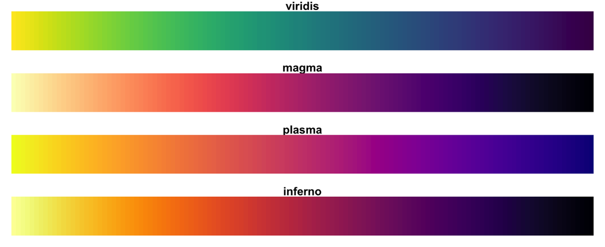

Viridis Color Palettes

1. viridis() - The default palette, suitable for sequential data.
2. plasma() - Suitable for sequential data with more vibrant colors.
3. inferno() - Suitable for sequential data with a fiery color scheme.
4. magma() - Suitable for sequential data with a dark, contrasting color scheme.
5. cividis() - Suitable for sequential data while maintaining accessibility for individuals with color vision deficiencies.

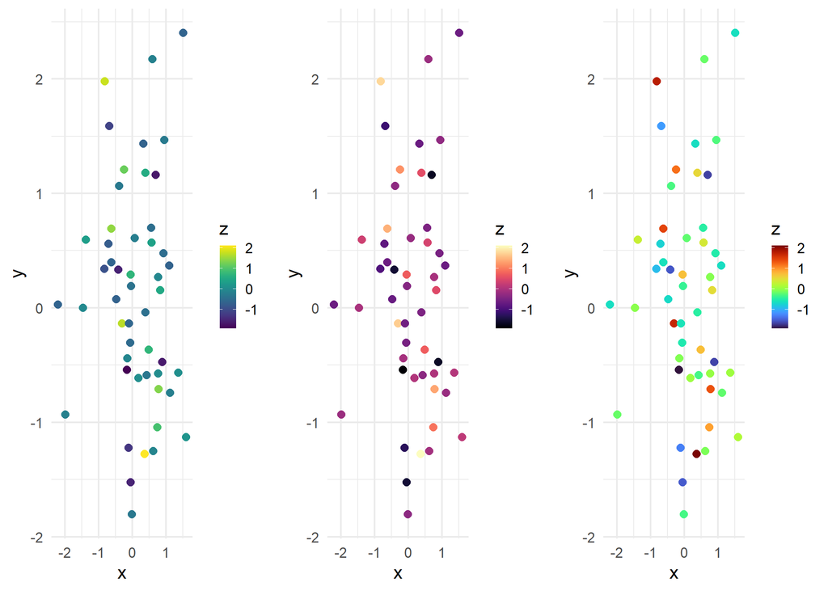

```r
# Generate random data

set.seed(1)
data <- data.frame(
  x = rnorm(50),
  y = rnorm(50),
  z = rnorm(50)
)

plot1 <- ggplot(data, aes(x = x, y = y, fill = z)) +
  geom_point(shape = 21, size = 2, color = "transparent") +
  scale_fill_viridis() +  # Use default color palette
  theme_minimal()+
  theme(legend.key.size = unit(0.7, "lines"))

plot2 <- ggplot(data, aes(x = x, y = y, fill = z)) +
  geom_point(shape = 21, size = 2, color = "transparent") +
  scale_fill_viridis(option = "magma") +  # Use Magma color palette
  theme_minimal()+
  theme(legend.key.size = unit(0.7, "lines"))

plot3 <-ggplot(data, aes(x = x, y = y, fill = z)) +
  geom_point(shape = 21, size = 2, color = "transparent") +
  scale_fill_viridis(option = "turbo") +  # Use turbo color palette
  theme_minimal()+
  theme(legend.key.size = unit(0.7, "lines"))

grid.arrange(plot1, plot2, plot3, ncol = 3)
```

### Discrete vs Continuous

Beyond the basic options, Viridis provides additional options for different variations of the color palette, including the “_c” suffix for continuous scales and “_d” for discrete scales. For example:

1. scale_fill_viridis_c(): To apply a continuous Viridis color scale.
2. scale_fill_viridis_d(): To apply a discrete Viridis color scale.

#### Discrete Data Visualization

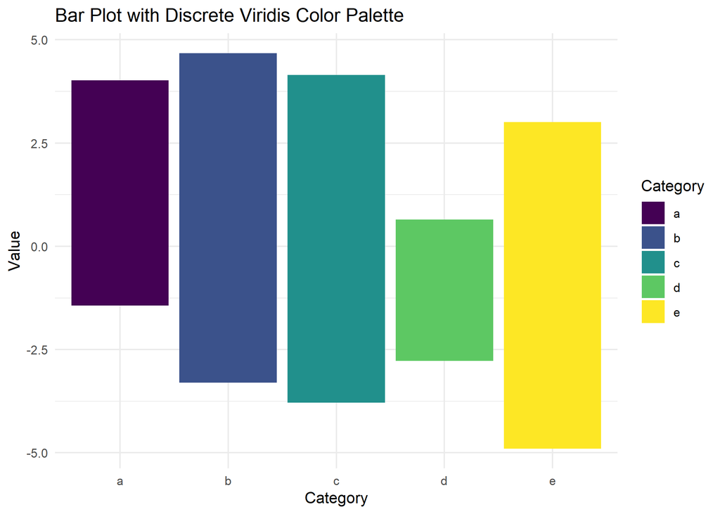

```r
# Generate random data with discrete categories
set.seed(123)
categories <- sample(letters[1:5], 50, replace = TRUE)
values <- rnorm(50)

data <- data.frame(Category = categories, Value = values)

# Create a bar plot with a discrete Viridis color palette
ggplot(data, aes(x = Category, y = Value, fill = Category)) +
  geom_bar(stat = "identity") +
  scale_fill_viridis_d(option = "v") +  # Using the discrete Viridis palette
  labs(title = "Bar Plot with Discrete Viridis Color Palette", x = "Category", y = "Value") +
  theme_minimal()
```

#### Continous Data Visualization

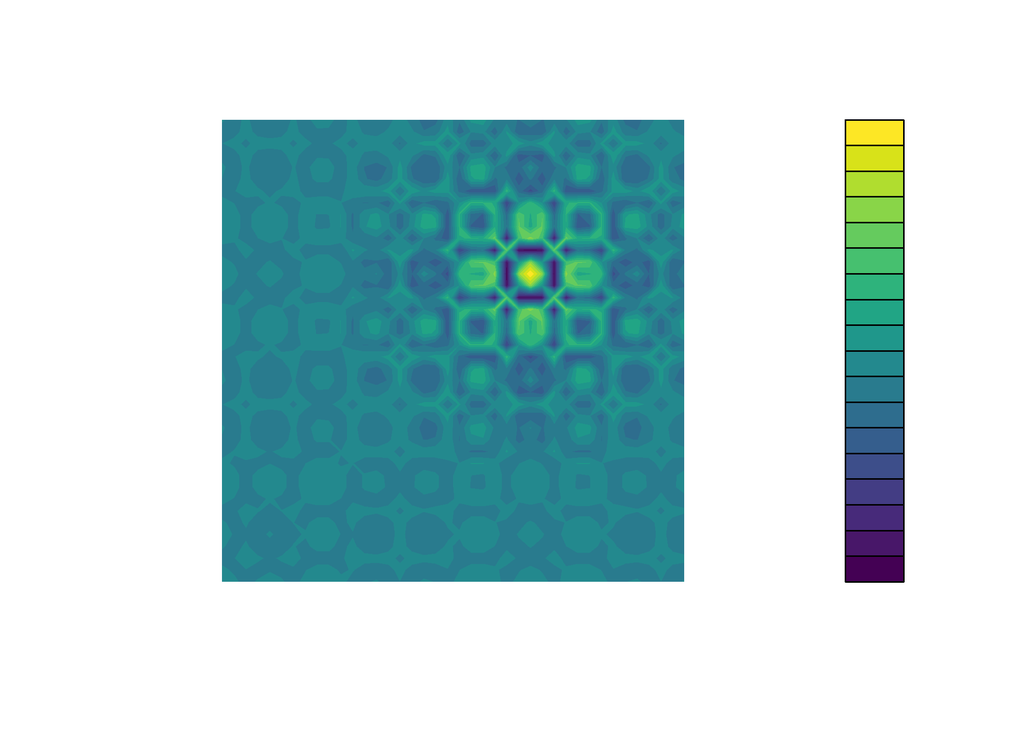

```r
x <- y <- seq(-7*pi, 3.5*pi, len = 40)
r <- sqrt(outer(x^2, y^2, "+"))
filled.contour(cos(r^2)*exp(-r/(2*pi)),
               axes=FALSE,
               color.palette=viridis,
               asp=1, title = "Bar Plot with Discrete Viridis Color Palette")
```

## Spatial Data Visualization with `viridis`

The following visualization plots the total population of various census tracts in Boston using the `viridis` package.

```r
tracts16 <-
  get_acs(geography = "tract",
          variables = c("B25026_001E"), #inc as % of rent
          year=2016,
          state = 25,
          county=025, #using the boston/suffolk county FIPS code
          geometry=TRUE, output="wide")%>%
  st_transform('ESRI:102728') %>%
  rename(TotalPop = B25026_001E)%>%
  dplyr::select(-NAME, -ends_with("M"))
```

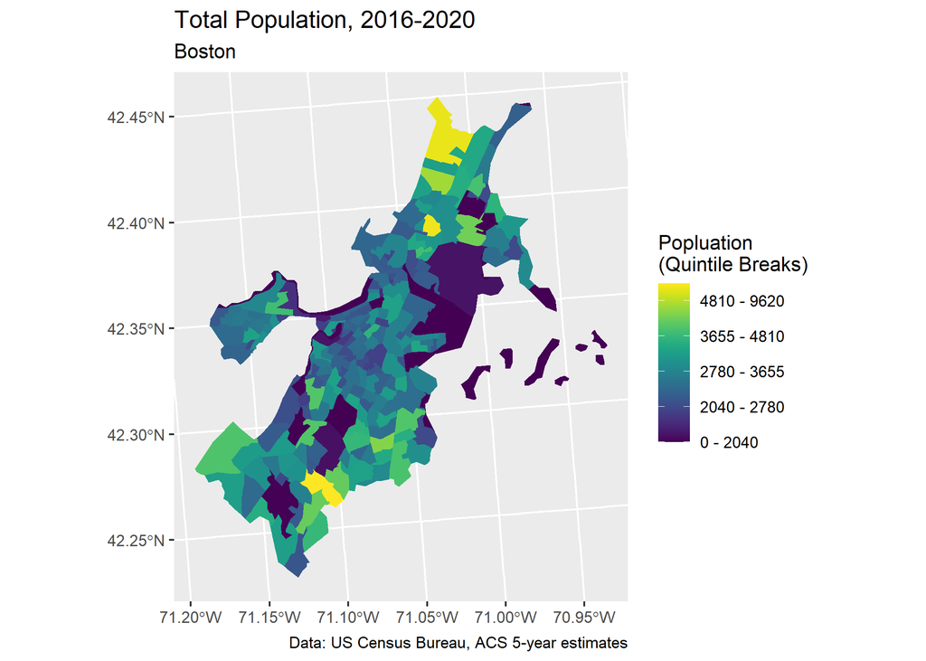

```r
ggplot()+
  geom_sf(data = tracts16, aes(fill = TotalPop), color="transparent")+
   scale_fill_viridis(labels = c("0 - 2040", "2040 - 2780", "2780 - 3655", "3655 - 4810", "4810 - 9620"),
                    name = "Popluation\n(Quintile Breaks)")  +
  labs(
    title = "Total Population, 2016-2020",
    subtitle = "Boston",
    caption = "Data: US Census Bureau, ACS 5-year estimates",
    fill = "Total Population")
```

We can also reverse the color palette by adding `direction = -1` to our `scale_fill_viridis` call.

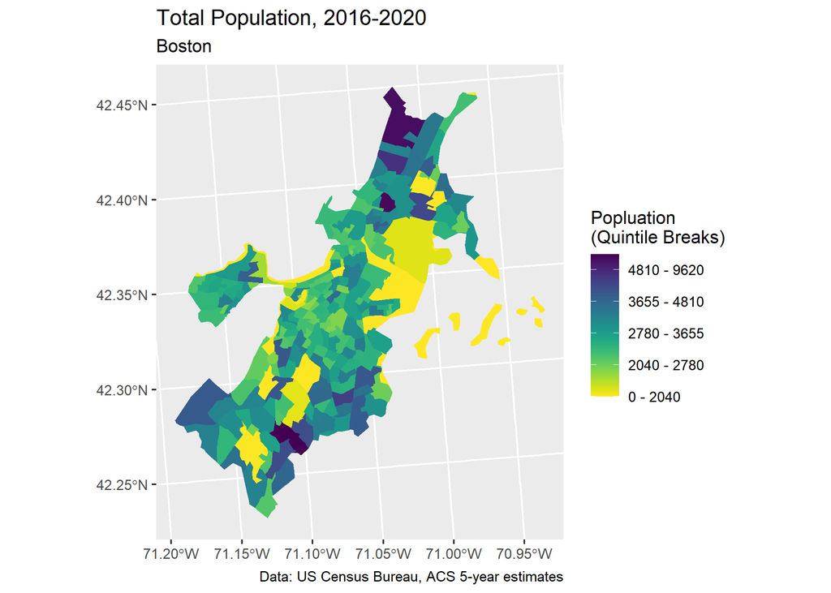

```r
ggplot()+
  geom_sf(data = tracts16, aes(fill = TotalPop), color="transparent")+
   scale_fill_viridis(direction = -1 , labels = c("0 - 2040", "2040 - 2780", "2780 - 3655", "3655 - 4810", "4810 - 9620"),
                    name = "Popluation\n(Quintile Breaks)")  +
  labs(
    title = "Total Population, 2016-2020",
    subtitle = "Boston",
    caption = "Data: US Census Bureau, ACS 5-year estimates",
    fill = "Total Population")
```

## Conclusion

In conclusion, the `viridis` color package has proven to be an invaluable tool in data visualization. `viridis` offers flexibility and compatibility with ggplot2, making it a top choice for enhancing the visual impact of data visualizations. Its versatility and aesthetic qualities have made it a go-to option for achieving a cohesive and engaging visual theme in data analysis and reporting.